# Multiple Linear Regression - Intro

Notes and in-class exercises

You can download the .qmd file for this activity here and open in R-studio. The rendered version is posted in the [course website](https://mutasim221b.github.io/Mac-STAT-155-Fall-25/) (Activities tab). I often experiment with the class activities (and see it in live!) and make updates, but I always post the final version before class starts. To be sure you have the most up-to-date copy, please download it once you’ve settled in before class begins.

# Notes

## Learning goals

By the end of this lesson, you should be familiar with:

- some limitations of **simple linear regression**
- the general goals behind **multiple linear regression**
- strategies for *visualizing* and *interpreting* multiple linear regression models of $Y$ vs 2 predictors, 1 quantitative and 1 categorical

## Readings and videos

Today is a day to discover ideas, so no readings or videos to go through before class.

## Motivation

**EXAMPLE 1**

Let’s explore some data on penguins. First, enter `install.packages("palmerpenguins")` in the *console* (not Rmd). Then load the `penguins` data. You can find a **codebook** for these data by typing `?penguins` in your *console* (not qmd).

```r
# Load packages
library(tidyverse)
data(penguins)
penguins <- penguins %>%
  filter(species != "Adelie", bill_len < 57)

# Check it out
head(penguins)
##   species island bill_len bill_dep flipper_len body_mass    sex year
## 1  Gentoo Biscoe     46.1     13.2         211      4500 female 2007
## 2  Gentoo Biscoe     50.0     16.3         230      5700   male 2007
## 3  Gentoo Biscoe     48.7     14.1         210      4450 female 2007
## 4  Gentoo Biscoe     50.0     15.2         218      5700   male 2007
## 5  Gentoo Biscoe     47.6     14.5         215      5400   male 2007
## 6  Gentoo Biscoe     46.5     13.5         210      4550 female 2007
```

Our goal is to build a model that we can use to get good predictions of penguins’ flipper (“arm”) lengths.

Consider 2 simple linear regression models of `flipper_len` by penguin `sex` and `species`:

```r
# Model 1: R-squared = 0.1205
summary(lm(flipper_len ~ sex, penguins))
##
## Call:
## lm(formula = flipper_len ~ sex, data = penguins)
##
## Residuals:
##    Min     1Q Median     3Q    Max
## -27.22 -10.22   3.78   8.78  17.37
##
## Coefficients:
##             Estimate Std. Error t value Pr(>|t|)
## (Intercept)  205.220      1.197 171.434  < 2e-16 ***
## sexmale        8.408      1.679   5.007  1.3e-06 ***
## ---
## Signif. codes:  0 '***' 0.001 '**' 0.01 '*' 0.05 '.' 0.1 ' ' 1
##
## Residual standard error: 11.42 on 183 degrees of freedom
##   (4 observations deleted due to missingness)
## Multiple R-squared:  0.1205, Adjusted R-squared:  0.1157
## F-statistic: 25.07 on 1 and 183 DF,  p-value: 1.297e-06

# Model 2: R-squared = 0.7014
summary(lm(flipper_len ~ species, penguins))
##
## Call:
## lm(formula = flipper_len ~ species, data = penguins)
##
## Residuals:
##     Min      1Q  Median      3Q     Max
## -18.045  -5.045  -1.045   3.955  15.955
##
## Coefficients:
##               Estimate Std. Error t value Pr(>|t|)
## (Intercept)   196.0448     0.8065  243.07   <2e-16 ***
## speciesGentoo  21.0372     1.0039   20.96   <2e-16 ***
## ---
## Signif. codes:  0 '***' 0.001 '**' 0.01 '*' 0.05 '.' 0.1 ' ' 1
##
## Residual standard error: 6.602 on 187 degrees of freedom
## Multiple R-squared:  0.7014, Adjusted R-squared:  0.6998
## F-statistic: 439.2 on 1 and 187 DF,  p-value: < 2.2e-16
```

How might we improve our predictions of `flipper_len` using only these 2 predictors? What do you think is a reasonable range of possible values for the new R-squared?

**EXAMPLE 2**

Consider a simple linear regression model of `flipper_len` by `bill_len`:

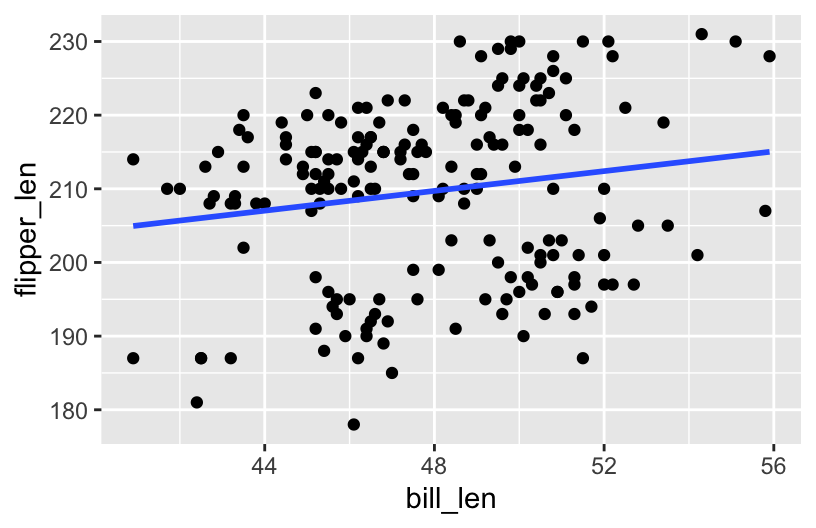

```r
penguins %>%
  ggplot(aes(y = flipper_len, x = bill_len)) +
  geom_point() +
  geom_smooth(method = "lm", se = FALSE)
```

Thoughts? What’s going on here? How does this highlight the limitations of a simple linear regression model?

**EXAMPLE 3**

The `cps` dataset contains employment information collected by the U.S. Current Population Survey (CPS) in 2018. We can use these data to explore wages among 18-34 year olds. The original codebook is [here](https://cps.ipums.org/cps/resources/codebooks/cpsmar18.pdf).

```r
# Import data
cps <- read_csv("https://mac-stat.github.io/data/cps_2018.csv") %>%
  select(-education, -hours) %>%
  filter(age >= 18, age <= 34) %>%
  filter(wage < 250000)
```

```r
# Check it out
head(cps)
## # A tibble: 6 × 6
##    wage   age marital industry   health    education_level
##   <dbl> <dbl> <chr>   <chr>      <chr>     <chr>
## 1 75000    33 single  management fair      bachelors
## 2 33000    19 single  management very_good bachelors
## 3 43000    33 married management good      bachelors
## 4 50000    32 single  management excellent HS
## 5 14400    28 single  service    excellent HS
## 6 33000    31 married management very_good bachelors
```

We can use a simple linear regression model to summarize the relationship of `wage` with `marital` status:

```r
# Build the model
wage_mod <- lm(wage ~ marital, data = cps)

# Summarize the model
coef(summary(wage_mod))
##                Estimate Std. Error   t value     Pr(>|t|)
## (Intercept)    46145.23    921.062  50.10002 0.000000e+00
## maritalsingle -17052.37   1127.177 -15.12839 5.636068e-50
```

What do you / don’t you conclude from this model? How does it highlight the limitations of a simple linear regression model?

**Reflection: Why are multiple regression models so useful?**

We can put more than 1 predictor into a regression model! Adding predictors to models…

- Predictive viewpoint: Helps us better predict the response
- Descriptive viewpoint: Helps us better understand the isolated (causal) effect of a variable by holding constant confounders

**Multiple linear regression model formula**

In general, a **multiple linear regression model** of $Y$ with multiple predictors $(X_1, X_2, ..., X_p)$ is represented by the following formula:

$$E[Y \mid X_1, X_2, ..., X_p] = \beta_0 + \beta_1 X_1 + \beta_2 X_2 + ... + \beta_p X_p$$

# Exercises

In the coming weeks, we’ll explore how to visualize, interpret, build, and evaluate multiple linear regression models.

First, we’ll explore some foundations using a model of penguin `flipper_len` by just 2 predictors: `bill_len` (quantitative) and `species` (categorical).

## Exercise 1: Visualizing the relationship

We’ve learned how to visualize the relationship of `flipper_len` by `bill_len` alone:

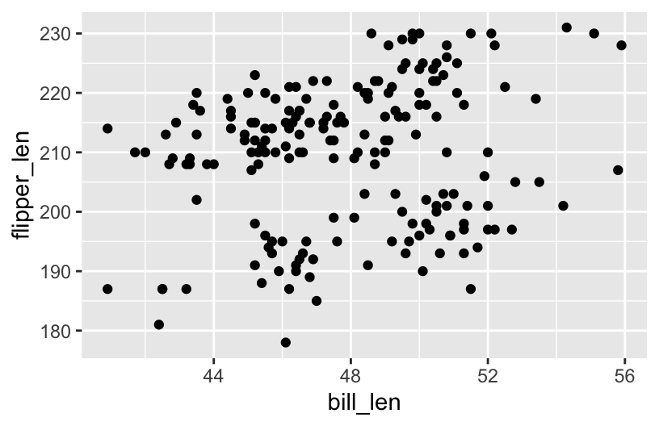

```r
penguins %>%
  ggplot(aes(y = flipper_len, x = bill_len)) +
  geom_point()
```

1. How might we change the scatterplot points to *also* indicate information about penguin `species`?

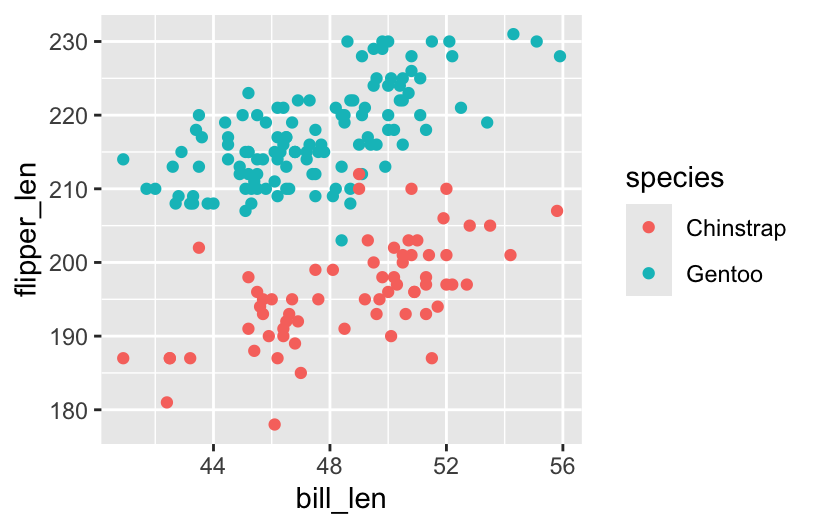

```r
penguins %>%
  ggplot(aes(y = flipper_len, x = bill_len, color = species)) +
  geom_point()
```

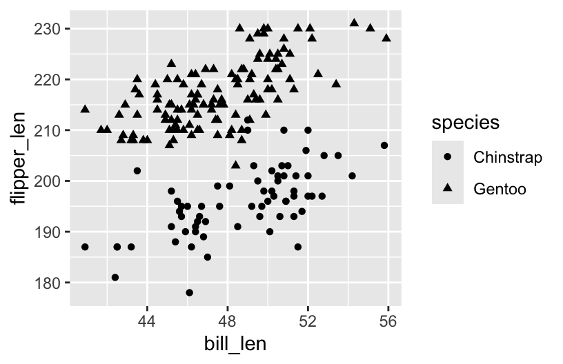

```r
penguins %>%
  ggplot(aes(y = flipper_len, x = bill_len, shape = species)) +
  geom_point()
```

## Exercise 2: Visualizing the model

We’ve also learned that a simple linear regression model of `flipper_len` by `bill_len` alone can be represented by a line:

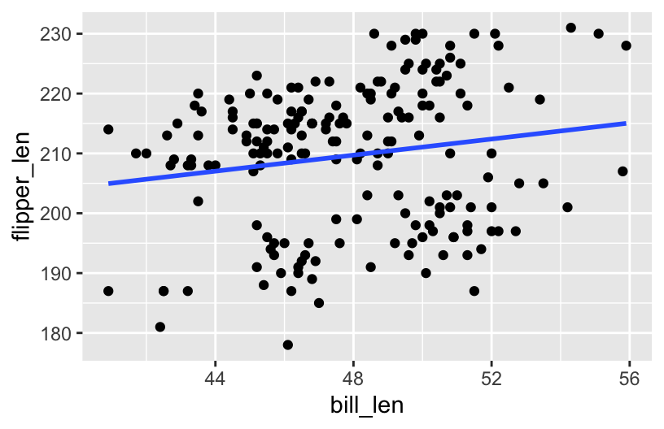

```r
penguins %>%
  ggplot(aes(y = flipper_len, x = bill_len)) +
  geom_point() +
  geom_smooth(method = "lm", se = FALSE)
```

1. Reflecting on your plot of `flipper_len` by `bill_len` and `species` in Exercise 1, how do you think a *multiple* regression model of `flipper_len` using *both* of these predictors would be represented? Check your intuition below by modifying the code below to include `species` in this plot, as you did in Exercise 1.

```r
penguins %>%
  ggplot(aes(y = flipper_len, x = bill_len, color = species)) +
  geom_point() +
  geom_smooth(method = "lm", se = FALSE)
```

[output not shown]

## Exercise 3: Intuition

Your plot in Exercise 2 demonstrated that the **multiple linear regression model** of `flipper_len` by `bill_len` and `species` is represented by 2 lines.

Let’s interpret the punchlines!

For each question, provide an answer along with evidence from the model lines that supports your answer.

1. What’s the relationship between `flipper_len` and `species`, no matter a penguin’s `bill_len`?

> **Response:** Put your response here.
2. What’s the relationship between `flipper_len` and `bill_len`, no matter a penguin’s `species`?

> **Response:** Put your response here.
3. Does the rate of increase in `flipper_len` with `bill_len` differ between the two `species`?

> **Response:** Put your response here.

## Exercise 4: Model formula

Of course, there’s a formula behind the multiple regression model. We can obtain this using the usual `lm()` function.

```r
# Build the model
penguin_mod <- lm(flipper_len ~ bill_len + species, data = penguins)

# Summarize the model
coef(summary(penguin_mod))
##                 Estimate Std. Error  t value     Pr(>|t|)
## (Intercept)   127.753693  6.1174521 20.88348 1.194472e-50
## bill_len        1.402367  0.1249665 11.22194 1.194932e-22
## speciesGentoo  22.848036  0.7938292 28.78206 1.981732e-70
```

1. In the `lm()` function, how did we communicate that we wanted to model `flipper_len` by both `bill_len` and `species`? bill_len + species
2. Complete the following model formula:

   E[flipper_len | bill_len, speciesGentoo] = 127.753693 + 1.402367 * bill_len + 22.848036 * speciesGentoo

## Exercise 5: Sub-model formulas

Ok. We now have a single *formula* for the model.

And we observed earlier that this formula is represented by two lines: one describing the relationship between `flipper_len` and `bill_len` for `Chinstrap` penguins and the other for `Gentoo` penguins.

Let’s bring these ideas together.

Utilize the model formula to obtain the equations of these two lines, i.e. to obtain the *sub-model formulas* for the 2 species. Hint: Plug speciesGentoo = 1 and speciesGentoo = 0

Chinstrap: flipper_len = 127.753693 + 1.402367* bill_len

Gentoo: flipper_len = (127.753693 +22.848036) + 1.402367 * bill_len

## Exercise 6: coefficients – physical interpretation

Reflecting on Exercise 5, let’s interpret what the model coefficients tell us about the *physical* properties of the two 2 sub-model lines. Choose the correct option given in parentheses:

1. The intercept coefficient, 127.75, is the intercept of the line for (Chinstrap / Gentoo) penguins.
2. The `bill_len` coefficient, 1.40, is the (intercept / slope) of both lines.
3. The `speciesGentoo` coefficient, 22.85, indicates that the (intercept / slope) of the line for Gentoo is 22.85mm higher than the (intercept / slope) of the line for Chinstrap. Similarly, since the lines are parallel, the line for Gentoo is 22.85mm higher than the line for Chinstrap at any `bill_len`.